# Switzerland COVID-19 Scenario Report

Updated 2020-04-24

Joseph Lemaitre (École Polytechnique Fédérale de Lausanne, EPFL), Javier Perez-Saez (Johns Hopkins University, JHU), Andrew Azman (JHU), Andrea Rinaldo (EPFL), Jacques Fellay (EPFL).

**FOR PLANNING PURPOSES ONLY: NOT A FORECAST**

**EDIT as of June 4, 2020:** This report is currently outdated and has not been updated since April 24, 2020. Older versions of this report are available on github. R0 estimations (see Inference tab) has been published [here](https://smw.ch/article/doi/smw.2020.20295). Another group provide updated R0 estimation on the [NCS-TF website](https://ncs-tf.ch/de/lagebericht)

## Scenarios

This report compares the health impact and surge capacity needs for the COVID-19 epidemic in Switzerland. The underlying model is based on our best understanding of SARS-CoV-2 natural history and transmission, and uses current demographic and epidemiologic data from Switzerland and other locations. We project the number of hospitalizations, ICU admissions, and deaths in both the short and long term under different public-health intervention scenarios.

#### Scenario definition

We compared 3 intervention scenarios for model simulations from January 31, 2020 through October 01, 2020:

We consider three planning scenarios:

- **Current Measures Stopped May 1st**, which assumes measures instituted in Switzerland:
  - School closure on March 14,
  - Physical distancing measures progressively established from March 14 to March 20.

are held up until May 1st. We inferred the impact of these moderately restrictive non-pharmaceutical interventions (NPIs) in Switzerland using data on hospitalizations and deaths (see Inference tab above). For May 1st on, we assume a return to baseline, **early epidemic level transmissibility** for the foreseeable future.

- **R0 around 1.2**, which assumes that current measures are replaced from May 1st on by a combination of measures that keeps the $R_0$ around 1.2
- **R0 around 1.5**, which assumes that current measures are replaced from May 1st on by a combination of measures that keeps the $R_0$ around 1.5.

### Scenario outcomes

#### Hospitalization

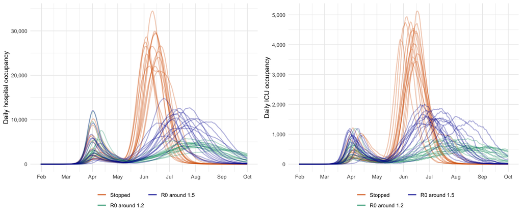

**Fig. 1**: Daily hospital occupancy for 15 simulation realizations for three scenarios with current measures until May 1st followed by 1) a return to baseline transmissiblity, 2) measures that keeps R0 around 1.2 and 3) measures that keeps R0 around 1.5.

Table 1. Median and 95%PI of several modeled variable on three timeframes.

|  | May 15 median | May 15 95% PI | June 15 median | June 15 95% PI | September 15 median | September 15 95% PI |
| --- | --- | --- | --- | --- | --- | --- |
| **Peak current hospitalizations** |  |  |  |  |  |  |
| Stopped | 4,000 | (1,100-9,000) | 27,000 | (15,000-30,000) | 27,000 | (20,000-30,000) |
| R0 around 1.2 | 4,000 | (1,000-9,000) | 4,000 | (1,100-9,000) | 5,000 | (2,800-9,000) |
| R0 around 1.5 | 4,000 | (1,000-10,000) | 6,000 | (2,300-12,000) | 11,000 | (8,000-15,000) |
| **Peak current ICUs** |  |  |  |  |  |  |
| Stopped | 600 | (180-1,500) | 4,000 | (2,300-5,000) | 4,000 | (3,100-5,000) |
| R0 around 1.2 | 500 | (160-1,400) | 600 | (180-1,400) | 800 | (400-1,400) |
| R0 around 1.5 | 700 | (150-1,600) | 900 | (310-1,800) | 1,600 | (1,200-2,200) |
| **Cumulative infections** |  |  |  |  |  |  |
| Stopped | 1,000,000 | (400,000-2,200,000) | 6,000,000 | (4,000,000-7,000,000) | 8,000,000 | (6,000,000-8,000,000) |
| R0 around 1.2 | 800,000 | (280,000-1,800,000) | 1,200,000 | (500,000-2,400,000) | 4,000,000 | (2,100,000-5,000,000) |
| R0 around 1.5 | 1,000,000 | (280,000-2,000,000) | 2,100,000 | (800,000-4,000,000) | 6,000,000 | (5,000,000-6,000,000) |
| **Cumulative ICUs** |  |  |  |  |  |  |
| Stopped | 2,600 | (900-5,000) | 15,000 | (6,000-22,000) | 24,000 | (20,000-25,000) |
| R0 around 1.2 | 2,400 | (800-5,000) | 3,000 | (1,200-7,000) | 11,000 | (6,000-14,000) |
| R0 around 1.5 | 2,900 | (800-6,000) | 5,000 | (1,600-10,000) | 18,000 | (14,000-19,000) |
| **Cumulative hospitalizations** |  |  |  |  |  |  |
| Stopped | 14,000 | (5,000-28,000) | 80,000 | (31,000-110,000) | 120,000 | (100,000-120,000) |
| R0 around 1.2 | 12,000 | (4,000-27,000) | 16,000 | (6,000-40,000) | 60,000 | (31,000-70,000) |
| R0 around 1.5 | 15,000 | (4,000-30,000) | 28,000 | (9,000-50,000) | 90,000 | (70,000-90,000) |
| **Cumulative deaths** |  |  |  |  |  |  |
| Stopped | 2,300 | (800-6,000) | 13,000 | (2,200-23,000) | 26,000 | (22,000-27,000) |
| R0 around 1.2 | 2,400 | (600-6,000) | 3,000 | (1,000-7,000) | 12,000 | (5,000-15,000) |
| R0 around 1.5 | 2,900 | (800-7,000) | 5,000 | (1,300-10,000) | 19,000 | (15,000-21,000) |

#### ICU capacity

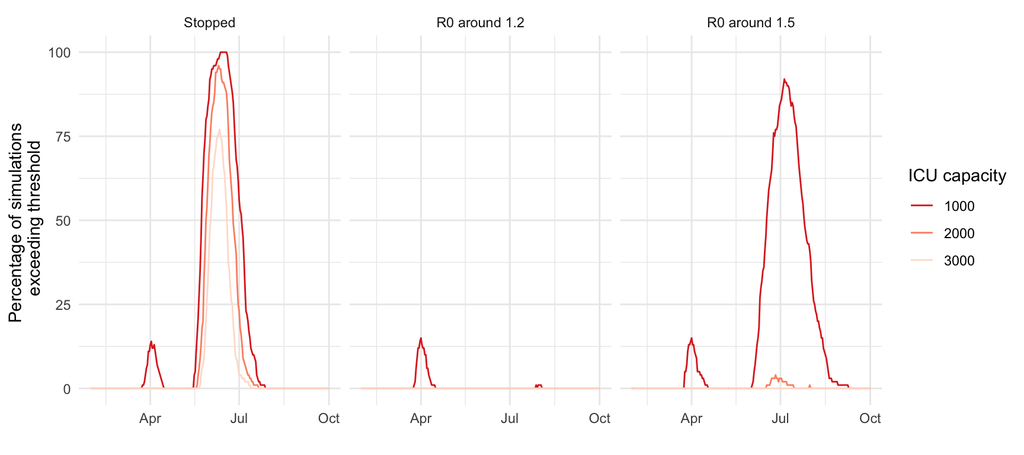

**Fig. 2**: Probability of exceedence of ICU capacity thresholds for three scenarios with current measures until May 1st followed by 1) a return to baseline transmissiblity, 2) measures that keeps R0 around 1.2 and 3) measures that keeps R0 around 1.5.

### Software

**Using the Pipeline from Johns Hopkins [ID Dynamics Working Group](http://www.iddynamics.jhsph.edu/):**

- EPFL: Joseph Lemaitre
- JHU: Kyra H. Grantz, Joshua Kaminsky, Steve Lauer, Elizabeth C. Lee, Justin Lessler, Hannah R. Meredith, Shaun A. Truelove.
- University of Utah: Lindsay T. Keegan
- Developper without affiliations: Sam Shah, Josh Wills
- [Open-Source Software](https://github.com/HopkinsIDD/COVIDScenarioPipeline)

## Methods

### Model assumptions

We built a spatial, stochastic, Susceptible-Exposed-Infected-Recovered (SEIR) model of SARS-CoV-2 transmission in Switzerland.

**Population.** The total population was collected from the website of the Swiss Federal Statistical Office. The entire population is assumed to be susceptible at the beginning of the model. We assume equal risk of infection for all individuals at a given time.

**Mobility** Data from Office Fédéral du développement territorial: VM-UVEK (2019): Verkehrsmodellierung im UVEK; Daten Zustand 2017. Zenodo: http://doi.org/10.5281/zenodo.3716134.

**Initial conditions.** We fit our initial conditions for each canton using our inference model. Our likelyhood uses cases, death and hospitalization, and output the number of infected at the start of the model. Baseline transmissibility in the model was estimated with the available epidemiological data (see Section “Inference”).

**COVID-19 Natural History.** From analysis of 181 confirmed SARS-CoV-2 cases among travelers and other publicly reported cases, Lauer et al. estimate the incubation period, or the time from exposure to symptom onset, to follow an exponential distribution with mean 5.2 days (IQR 1.5, 7.21 days). The average duration of infectiousness following symptom onset is between 1.3 days and 3, following an Erlang distribution with 3 compartments. We thus sample across a range of possible mean serial intervals (time from symptom onset of an index case to symptom onset of a secondary case infected by the index) from 6.5 to 8.2 days.

**Filtering.** Simulated time series of incidence and hospitalizations are based on 30’000 random draws from reasonable bounds of the parameter values. Among these draws, we resample to narrow the set to a simulation that matches the observed reality in hospitalization. Namely, we assign to each simulation a weight that is proportional to the likelihood of incident hospitalizations.

We use simple statistical models using the cumulative distribution of times to hospitalization, ICU admission, and death, as well as the durations of hospitalization and ICU stay to calculate the number of incident and cumulative hospitalizations and ICU admissions and deaths per day, accounting for appropriate delays since infection and symptom onset.

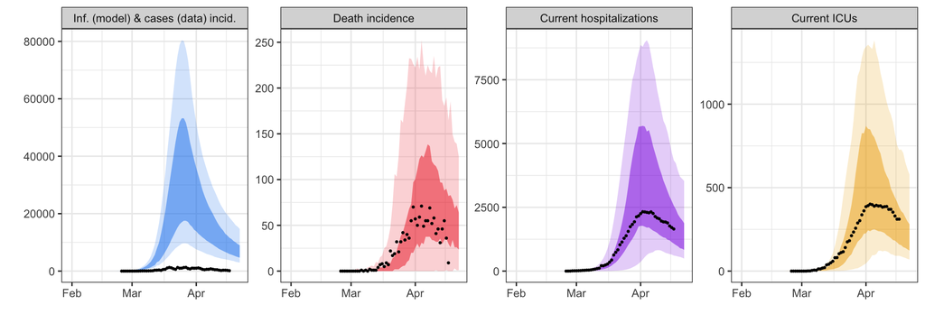

### Limitations

We note several limitations to our work, among which:

There remains considerable uncertainty around some of the key epidemiologic features of COVID-19, including the average duration of infectiousness and time to recovery or death. We have used commonly accepted and well supported estimates as well as hospitalization data from the canton of Vaud up till April 8th, and believe that they are appropriate for planning purposes.

We assume equal risk of infection and progression to hospitalization or death among all individuals in the country at a given time point. There is evidence of age-specific differences in clinical burden and perhaps in susceptibility to infection that are not (yet) considered here.

We do not explicitly model the role of asymptomatic infection when calculating the number of expected hospitalizations. All infectious individuals are considered at risk of hospitalization, though some may recover or die prior to hospitalization. A substantial asymptomatic burden may reduce the number of hospitalized cases.

We do not consider changes in intercantonal mobility from the NPI in place, but we plan to do so in the near future.

### Key Sources

- School closure impacts based on data from (Jackson et al. 2020), (Cauchemez et al. 2008) and (Litvinova et al. 2019)
- Approximate generation time is based on data from (Bi et al. 2020)
- Serial interval and incubation period from (Lauer et al. 2020)
- All the hospitalisation parameters: time in ICU, time to discharge, time to death, percent that die in hospital, … comes from our study of Canton de Vaud data.

## Inference

### Inference methods

**Infection dynamics and hospitalization model** We implement for inference a stochastic dynamical model of the epidemic and hospitalization processes based on the SEIR template used for our scenario generation. The infection dynamics part of the model is the same as the one used for scenario building. Hospitalization dynamics are here modelled explicitely, as opposed to the statistical approach used in scenario buidling. This is done so as to allow the formulation of data likelihood functions which incorporate them. The model assumes that infected people have a certain probability of developing severe symptoms, which then either are hospitalized or not. Infected can dye either outside of the hospital system or within it, either in an ICU or not. The number of compartments in each stage of the disease is determined by fitting an Erlang distribution to the observed times of each transition between classes. These were determing based on hospital data from VD up to April 8th.

**Inference** We fit the model to curated data from [OpenZH](https://github.com/openZH/covid_19), available [here](https://github.com/daenuprobst/covid19-cases-switzerland) These include the current number of hospitalized COVID patients, and the cumulative numbers of deaths, cases and hospital discharges. The latter was not available in all cantons. Time-varying transmission $R_0(t)$ was estimated following a similar approach than that in (Cazelles 2018), with assumptions on the natural history of SARS-CoV-2 detailed in the Methods section.

We choose to only use deaths and hospitalizations for model estimation due to the challenges linked to COVID-19 case identification and heterogenous testing strategies adopted across cantons. The observation model is formulated as follows:

$$\begin{aligned}
deaths(t) &\sim Poisson(\Delta D(t)) \\
\Delta hosp(t) &\sim Skellam(\Delta H(t), \Delta D_H(t) + \Delta R_H(t)) \\
\end{aligned}$$
where, $\Delta I(t)$, $\Delta D(t)$, $\Delta H(t)$, $\Delta D_H(t)$, $\Delta R_H(t)$ are respectively the number of new infected, deaths, hospitalized, and deaths and discharged from hospitals at time $t$, and $\Delta hosp(t)$ is the difference between the number of current hospitalizations at times $t$ and $t-1$, for which we choose a [Skellam distribution](https://en.wikipedia.org/wiki/Skellam_distribution). The full log-likelihood of the observation model was taken as the sum of the individual log-likelihoods of the two data types. The model was fit using multiple-iterated filtering as implemented by (Ionides et al. 2015) in the [POMP](https://kingaa.github.io/pomp/) R package.

### Estimates of time-varying $R_0$

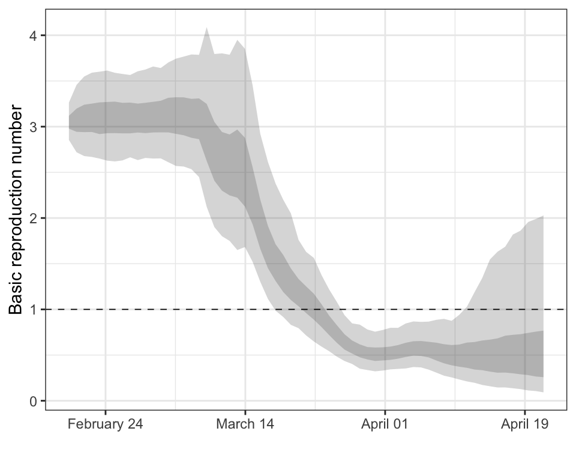

### Fit to data

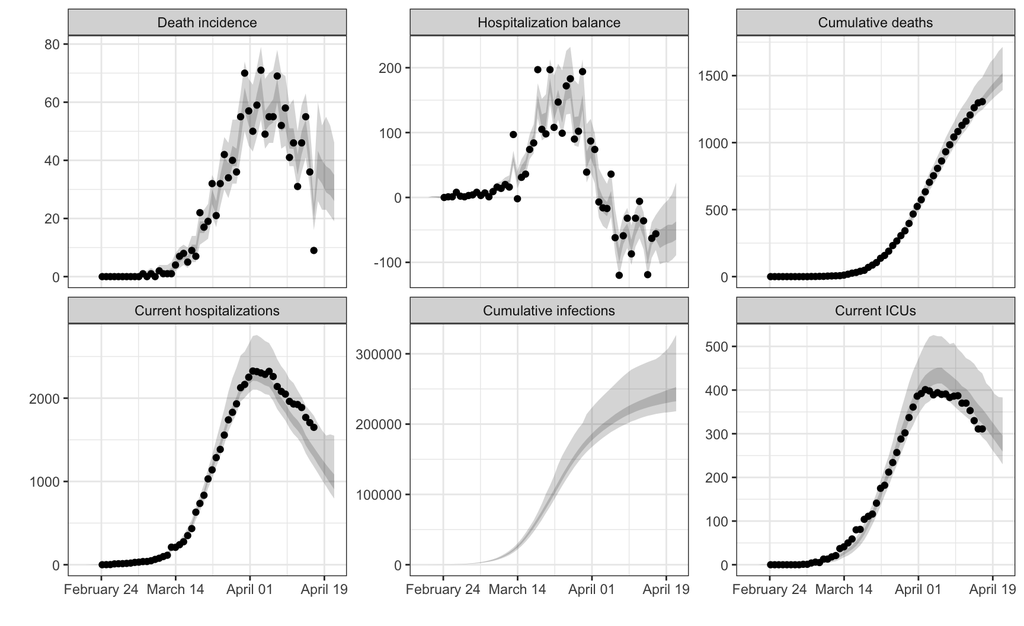

## References

Bi, Qifang, Yongsheng Wu, Shujiang Mei, Chenfei Ye, Xuan Zou, Zhen Zhang, Xiaojian Liu, et al. 2020. “Epidemiology and Transmission of COVID-19 in Shenzhen China: Analysis of 391 Cases and 1,286 of Their Close Contacts,” March. https://doi.org/10.1101/2020.03.03.20028423.

Cauchemez, Simon, Alain-Jacques Valleron, Pierre-Yves Boëlle, Antoine Flahault, and Neil M. Ferguson. 2008. “Estimating the Impact of School Closure on Influenza Transmission from Sentinel Data.” *Nature* 452 (7188): 750–54. https://doi.org/10.1038/nature06732.

Cazelles, Clara AND Dureau, Bernard AND Champagne. 2018. “Accounting for Non-Stationarity in Epidemiology by Embedding Time-Varying Parameters in Stochastic Models.” *PLOS Computational Biology* 14 (8): 1–26. https://doi.org/10.1371/journal.pcbi.1006211.

Ionides, Edward L., Dao Nguyen, Yves Atchadé, Stilian Stoev, and Aaron A. King. 2015. “Inference for Dynamic and Latent Variable Models via Iterated, Perturbed Bayes Maps.” *Proceedings of the National Academy of Sciences* 112 (3): 719–24. https://doi.org/10.1073/pnas.1410597112.

Jackson, Michael L, Gregory R Hart, Denise J McCulloch, Amanda Adler, Elisabeth Brandstetter, Kairsten Fay, Peter Han, et al. 2020. “Effects of Weather-Related Social Distancing on City-Scale Transmission of Respiratory Viruses,” March. https://doi.org/10.1101/2020.03.02.20027599.

Lauer, Stephen A, Kyra H Grantz, Qifang Bi, Forrest K Jones, Qulu Zheng, Hannah Meredith, Andrew S Azman, Nicholas G Reich, and Justin Lessler. 2020. “The Incubation Period of 2019-nCoV from Publicly Reported Confirmed Cases: Estimation and Application.” *medRxiv*. https://doi.org/10.1101/2020.02.02.20020016.

Litvinova, Maria, Quan-Hui Liu, Evgeny S. Kulikov, and Marco Ajelli. 2019. “Reactive School Closure Weakens the Network of Social Interactions and Reduces the Spread of Influenza.” *Proceedings of the National Academy of Sciences* 116 (27): 13174–81. https://doi.org/10.1073/pnas.1821298116.